# STAT 331 Portfolio

Author

Kristen Ho

**My Grade:** I believe my grade equivalent to course work evidenced below to be an A.

**Learning Objective Evidence:** In the code chunks below, provide code from Lab or Challenge assignments where you believe you have demonstrated proficiency with the specified learning target. Be sure to specify **where** the code came from (e.g., Lab 4 Question 2).

## Working with Data

**WD-1: I can import data from a *variety* of formats (e.g., csv, xlsx, txt, etc.).**

- `csv` Example 1

```r
#Lab 2, Question 1
surveys <- read_csv(here::here("Week 2", "Lab 2", "surveys.csv"))
```

- `csv` Example 2

```r
#Lab 3, Question 2
evals <- read_csv(here::here("Week 3", "Lab 3", "teacher_evals.csv"))
```

- `xlsx`

```r
# Practice Activity 4
military <- read_xlsx("gov_spending_per_capita.xlsx",
                      sheet = "Share of Govt. spending",
                      skip  = 7,
                      n_max = 191,
                      na = c(". .", "xxx", "..")
                      )
```

**WD-2: I can select necessary columns from a dataset.**

- Example selecting specified columns

```r
#Lab 3, Question 5
teacher_evals_clean <- evals |>
  rename(sex = gender) |>
  mutate(teacher_id = as.character(teacher_id),
         question_no = as.character(question_no),
         across(
           .cols = c(no_participants,
                     resp_share,
                     SET_score_avg,
                     percent_failed_cur,
                     seniority),
           .fns = ~ as.numeric(.x)
           )
         )|>
  filter(no_participants > 10) |>
  select(course_id,
         teacher_id,
         question_no,
         no_participants,
         resp_share,
         SET_score_avg,
         percent_failed_cur,
         academic_degree,
         seniority,
         sex)
```

- Example removing specified columns

```r
#Lab 5, The woman who hired Jeremy Bowers
#Revisions: made a tibble for the suspect features to use a semi-join, removed event_id column, and mutated the date using lubridate

features <- tibble(car_make = "Tesla",
                   car_model = "Model S",
                   hair_color = "red",
                   gender = "female")

facebook_event_checkin |>
  select(-event_id) |>
  left_join(person, by = join_by(person_id == id)) |>
  left_join(drivers_license, by = join_by(license_id == id)) |>
  filter(height %in% c(65, 66, 67),
         str_detect(event_name, pattern = "SQL Symphony Concert"))|>
  semi_join(features, by = join_by(car_make,
                                   car_model,
                                   hair_color,
                                   gender)) |>
  mutate(date = ymd(date))|>
  filter(year(date) == 2017,
         month(date) == 12) |>
  group_by(person_id) |>
  summarize(event_count  = n()) |>
  filter(event_count == 3) |>
  left_join(person, by = join_by(person_id == id)) |>
  pull(person_id, name)
```

- Example selecting columns based on logical values (e.g., `starts_with()`, `ends_with()`, `contains()`, `where()`)

```r
#Lab 4, Question 7
#Revisions:Used colorRampPalette match the colors in the example graph, added starts_with() in select column

ca_childcare |>
  select(study_year, census_region, starts_with("mc_")) |>
  mutate(Infant = mc_infant,
         Toddler = mc_toddler,
         Preschool = mc_preschool) |>
  pivot_longer(cols = c(Infant, Toddler, Preschool),
               names_to = "childcare_center",
               values_to = "median_price") |>
  mutate(childcare_center = fct(childcare_center,
                                levels = c("Infant",
                                           "Toddler",
                                           "Preschool")))|>
  ggplot(mapping = aes(x = study_year,
                    y = median_price,
                    color = fct_reorder2(.f = census_region,
                                        .x = study_year,
                                        .y = median_price,
                                        .fun = last2,
                                        .desc = TRUE))) +
  scale_x_continuous(limits = c(2008, 2018),
                     breaks = seq(2008,2018,2)) +
  scale_y_continuous(limits = c(0,500),
                     breaks = seq(0,500, 100)) +
  scale_color_manual(values = colorRampPalette(brewer.pal(7, "Accent"))(10)) +
  geom_point() +
  geom_smooth(method = "loess",
              linewidth = 0.5,
              fill = "grey",
              alpha = 0.5) +
  facet_wrap(~childcare_center, scales = "free_x") +
  labs(title = "Weekly Median Price for Center-Based Childcare ($)",
       x = "Study Year",
       y = NULL,
       color = "California Region") +
  theme_bw() +
  theme(aspect.ratio = 1,
        axis.text.x = element_text(size = 6))
```

**WD-3: I can filter rows from a dataframe for a *variety* of data types (e.g., numeric, integer, character, factor, date).**

- Numeric Example 1

```r
#Lab 3, Question 5
teacher_evals_clean <- evals |>
  rename(sex = gender) |>
  mutate(teacher_id = as.character(teacher_id),
         question_no = as.character(question_no),
         across(
           .cols = c(no_participants,
                     resp_share,
                     SET_score_avg,
                     percent_failed_cur,
                     seniority),
           .fns = ~ as.numeric(.x)
           )
         )|>
  filter(no_participants > 10) |>
  select(course_id,
         teacher_id,
         question_no,
         no_participants,
         resp_share,
         SET_score_avg,
         percent_failed_cur,
         academic_degree,
         seniority,
         sex)
```

- Numeric Example 2

```r
# Challenge 3, Question 1
teacher_evals_compare <- evals |>
  filter(question_no == 903) |>
  mutate(set_level = if_else(SET_score_avg >= 4, "excellent", "standard"),
         sen_level = case_when(seniority <= 4 ~ "junior",
                               seniority <= 8 ~ "senior",
                               seniority > 8 ~ "very senior")) |>
  select(course_id, set_level, sen_level)
```

- Character Example 1 (any context)

```r
#Lab 5, The woman who hired Jeremy Bowers
#Revisions: made a tibble for the suspect features to use a semi-join, removed event_id column, and mutated the date using lubridate

features <- tibble(car_make = "Tesla",
                   car_model = "Model S",
                   hair_color = "red",
                   gender = "female")

facebook_event_checkin |>
  select(-event_id) |>
  left_join(person, by = join_by(person_id == id)) |>
  left_join(drivers_license, by = join_by(license_id == id)) |>
  filter(height %in% c(65, 66, 67),
         str_detect(event_name, pattern = "SQL Symphony Concert"))|>
  semi_join(features, by = join_by(car_make,
                                   car_model,
                                   hair_color,
                                   gender)) |>
  mutate(date = ymd(date))|>
  filter(year(date) == 2017,
         month(date) == 12) |>
  group_by(person_id) |>
  summarize(event_count  = n()) |>
  filter(event_count == 3) |>
  left_join(person, by = join_by(person_id == id)) |>
  pull(person_id, name)
```

- Character Example 2 (example must use functions from **stringr**)

```r
#Lab 5, The woman who hired Jeremy Bowers
#Revisions: made a tibble for the suspect features to use a semi-join, removed event_id column, and mutated the date using lubridate

features <- tibble(car_make = "Tesla",
                   car_model = "Model S",
                   hair_color = "red",
                   gender = "female")

facebook_event_checkin |>
  select(-event_id) |>
  left_join(person, by = join_by(person_id == id)) |>
  left_join(drivers_license, by = join_by(license_id == id)) |>
  filter(height %in% c(65, 66, 67),
         str_detect(event_name, pattern = "SQL Symphony Concert"))|>
  semi_join(features, by = join_by(car_make,
                                   car_model,
                                   hair_color,
                                   gender)) |>
  mutate(date = ymd(date))|>
  filter(year(date) == 2017,
         month(date) == 12) |>
  group_by(person_id) |>
  summarize(event_count  = n()) |>
  filter(event_count == 3) |>
  left_join(person, by = join_by(person_id == id)) |>
  pull(person_id, name)
```

- Date (example must use functions from **lubridate**)

```r
#Lab 5, The woman who hired Jeremy Bowers
#Revisions: made a tibble for the suspect features to use a semi-join, removed event_id column, and mutated the date using lubridate

features <- tibble(car_make = "Tesla",
                   car_model = "Model S",
                   hair_color = "red",
                   gender = "female")

facebook_event_checkin |>
  select(-event_id) |>
  left_join(person, by = join_by(person_id == id)) |>
  left_join(drivers_license, by = join_by(license_id == id)) |>
  filter(height %in% c(65, 66, 67),
         str_detect(event_name, pattern = "SQL Symphony Concert"))|>
  semi_join(features, by = join_by(car_make,
                                   car_model,
                                   hair_color,
                                   gender)) |>
  mutate(date = ymd(date))|>
  filter(year(date) == 2017,
         month(date) == 12) |>
  group_by(person_id) |>
  summarize(event_count  = n()) |>
  filter(event_count == 3) |>
  left_join(person, by = join_by(person_id == id)) |>
  pull(person_id, name)
```

**WD-4: I can modify existing variables and create new variables in a dataframe for a *variety* of data types (e.g., numeric, integer, character, factor, date).**

- Numeric Example 1

```r
#Lab 3, Question 5
teacher_evals_clean <- evals |>
  rename(sex = gender) |>
  mutate(teacher_id = as.character(teacher_id),
         question_no = as.character(question_no),
         across(
           .cols = c(no_participants,
                     resp_share,
                     SET_score_avg,
                     percent_failed_cur,
                     seniority),
           .fns = ~ as.numeric(.x)
           )
         )|>
  filter(no_participants > 10) |>
  select(course_id,
         teacher_id,
         question_no,
         no_participants,
         resp_share,
         SET_score_avg,
         percent_failed_cur,
         academic_degree,
         seniority,
         sex)
```

- Numeric Example 2

```r
# Challenge 3, Question 1
teacher_evals_compare <- evals |>
  filter(question_no == 903) |>
  mutate(set_level = if_else(SET_score_avg >= 4, "excellent", "standard"),
         sen_level = case_when(seniority <= 4 ~ "junior",
                               seniority <= 8 ~ "senior",
                               seniority > 8 ~ "very senior")) |>
  select(course_id, set_level, sen_level)
```

- Factor Example 1 (renaming levels)

```r
#Lab 4, Question 4
#Feedback: You should only call the mutate() function once

ca_childcare <- ca_childcare |>
  mutate(county_name = str_remove(county_name, " County"),
         census_region = fct_collapse(.f = county_name,
                                      "Superior County" = superior_counties,
                                      "North Coast" = north_coast_counties,
                                      "San Francisco Bay Area"  = san_fran_counties,
                                      "Central Coast" = central_coast_counties,
                                      "Southern San Joaquin Valley" = s_san_joaquin_counties,
                                      "Northern San Joaquin Valley" = n_san_joaquin_counties,
                                      "Inland Empire" = inland_counties,
                                      "Los Angeles County" = la_county,
                                      "Orange County" = orange_county,
                                      "San Diego-Imperial" = san_diego_imperial_counties
                                      ))
```

- Factor Example 2 (reordering levels)

```r
#Lab 4, Question 7
#Revisions:Used colorRampPalette match the colors in the example graph, added starts_with() in select column

ca_childcare |>
  select(study_year, census_region, starts_with("mc_")) |>
  mutate(Infant = mc_infant,
         Toddler = mc_toddler,
         Preschool = mc_preschool) |>
  pivot_longer(cols = c(Infant, Toddler, Preschool),
               names_to = "childcare_center",
               values_to = "median_price") |>
  mutate(childcare_center = fct(childcare_center,
                                levels = c("Infant",
                                           "Toddler",
                                           "Preschool")))|>
  ggplot(mapping = aes(x = study_year,
                    y = median_price,
                    color = fct_reorder2(.f = census_region,
                                        .x = study_year,
                                        .y = median_price,
                                        .fun = last2,
                                        .desc = TRUE))) +
  scale_x_continuous(limits = c(2008, 2018),
                     breaks = seq(2008,2018,2)) +
  scale_y_continuous(limits = c(0,500),
                     breaks = seq(0,500, 100)) +
  scale_color_manual(values = colorRampPalette(brewer.pal(7, "Accent"))(10)) +
  geom_point() +
  geom_smooth(method = "loess",
              linewidth = 0.5,
              fill = "grey",
              alpha = 0.5) +
  facet_wrap(~childcare_center, scales = "free_x") +
  labs(title = "Weekly Median Price for Center-Based Childcare ($)",
       x = "Study Year",
       y = NULL,
       color = "California Region") +
  theme_bw() +
  theme(aspect.ratio = 1,
        axis.text.x = element_text(size = 6))
```

- Character (example must use functions from **stringr**)

```r
# Lab 8, Question 3
# Feedback: You should be able to remove the _ in one line of code.
# Revision: Replaced all _ in one line and edited the labels within the titles to make the plot look cleaner and the code more tidy

plot_design <- function(df, x, y, var = island){

  x_label <- as_label(enquo(x)) |>
              str_replace_all("_", " ") |>
              str_to_title()

  y_label <- as_label(enquo(y)) |>
              str_replace_all("_", " ") |>
              str_to_title()

 label <- rlang::englue("Correlation Between {str_replace(x_label, '[^ ]*$', '')}and {str_replace(y_label, '[^ ]*$', '')}based on {str_to_title(as_label(enquo(var)))}")

  df |>
    ggplot(mapping = aes(x = {{x}},
                         y = {{y}},
                         color = {{var}})) +
    geom_point() +
    labs(title = label,
        x = x_label,
        y = y_label,
        color = str_to_title(as_label(enquo(var)))
    )
}
```

- Date (example must use functions from **lubridate**)

```r
#Lab 5, Finding suspects at the gym
#Revisions: mutated check_in_date with lubridate, changed left_join to inner_join

suspect_1 <- get_fit_now_check_in |>
  mutate(check_in_date = ymd(check_in_date)) |>
  left_join(get_fit_now_member, by = join_by(membership_id == id)) |>
  left_join(person, by = join_by(person_id == id, name == name)) |>
  inner_join(drivers_license, by = join_by(license_id == id)) |>
  filter(str_detect(membership_id, "^48Z"),
         membership_status == "gold",
         str_detect(plate_number, "H42W*"),
         year(check_in_date) == 2018,
         month(check_in_date) == 1,
         day(check_in_date) == 9)

suspect_1 |>
  pull(person_id, name)
```

**WD-5: I can use mutating joins to combine multiple dataframes.**

- `left_join()` Example 1

```r
#Lab 5, The woman who hired Jeremy Bowers
#Revisions: made a tibble for the suspect features to use a semi-join, removed event_id column, and mutated the date using lubridate

features <- tibble(car_make = "Tesla",
                   car_model = "Model S",
                   hair_color = "red",
                   gender = "female")

facebook_event_checkin |>
  select(-event_id) |>
  left_join(person, by = join_by(person_id == id)) |>
  left_join(drivers_license, by = join_by(license_id == id)) |>
  filter(height %in% c(65, 66, 67),
         str_detect(event_name, pattern = "SQL Symphony Concert"))|>
  semi_join(features, by = join_by(car_make,
                                   car_model,
                                   hair_color,
                                   gender)) |>
  mutate(date = ymd(date))|>
  filter(year(date) == 2017,
         month(date) == 12) |>
  group_by(person_id) |>
  summarize(event_count  = n()) |>
  filter(event_count == 3) |>
  left_join(person, by = join_by(person_id == id)) |>
  pull(person_id, name)
```

- `right_join()` Example 1

```r
#Lab 4, Question 3
ca_childcare <-
  right_join(x = ca_childcare,
            y = tax_rev,
            by = join_by(county_name == entity_name, study_year == year))
```

- `left_join()` **or** `right_join()` Example 2

```r
#Lab 5, Finding suspects at the gym
#Revisions: mutated check_in_date with lubridate, changed left_join to inner_join

suspect_1 <- get_fit_now_check_in |>
  mutate(check_in_date = ymd(check_in_date)) |>
  left_join(get_fit_now_member, by = join_by(membership_id == id)) |>
  left_join(person, by = join_by(person_id == id, name == name)) |>
  inner_join(drivers_license, by = join_by(license_id == id)) |>
  filter(str_detect(membership_id, "^48Z"),
         membership_status == "gold",
         str_detect(plate_number, "H42W*"),
         year(check_in_date) == 2018,
         month(check_in_date) == 1,
         day(check_in_date) == 9)

suspect_1 |>
  pull(person_id, name)
```

- `inner_join()` Example 1

```r
#Lab 4, Question 2
#Feedback: Technically, you don't need to use join_by() if both datasets have the same column names. You can simply use by = "county_fips_code".

ca_childcare <-
  filter(.data = counties, state_abbreviation == "CA") |>
  inner_join(y = childcare_costs,
            by = join_by(county_fips_code)) |>
  select(county_name, study_year, mcsa, mfccsa)
```

- `inner_join()` Example 2

```r
#Lab 5, Finding suspects at the gym
#Revisions: mutated check_in_date with lubridate, changed left_join to inner_join

suspect_1 <- get_fit_now_check_in |>
  mutate(check_in_date = ymd(check_in_date)) |>
  left_join(get_fit_now_member, by = join_by(membership_id == id)) |>
  left_join(person, by = join_by(person_id == id, name == name)) |>
  inner_join(drivers_license, by = join_by(license_id == id)) |>
  filter(str_detect(membership_id, "^48Z"),
         membership_status == "gold",
         str_detect(plate_number, "H42W*"),
         year(check_in_date) == 2018,
         month(check_in_date) == 1,
         day(check_in_date) == 9)

suspect_1 |>
  pull(person_id, name)
```

**WD-6: I can use filtering joins to filter rows from a dataframe.**

- `semi_join()`

```r
#Lab 5, The woman who hired Jeremy Bowers
#Revisions: made a tibble for the suspect features to use a semi-join, removed event_id column, and mutated the date using lubridate

features <- tibble(car_make = "Tesla",
                   car_model = "Model S",
                   hair_color = "red",
                   gender = "female")

facebook_event_checkin |>
  select(-event_id) |>
  left_join(person, by = join_by(person_id == id)) |>
  left_join(drivers_license, by = join_by(license_id == id)) |>
  filter(height %in% c(65, 66, 67),
         str_detect(event_name, pattern = "SQL Symphony Concert"))|>
  semi_join(features, by = join_by(car_make,
                                   car_model,
                                   hair_color,
                                   gender)) |>
  mutate(date = ymd(date))|>
  filter(year(date) == 2017,
         month(date) == 12) |>
  group_by(person_id) |>
  summarize(event_count  = n()) |>
  filter(event_count == 3) |>
  left_join(person, by = join_by(person_id == id)) |>
  pull(person_id, name)
```

- `anti_join()`

```r
#Lab 5: Analyzing further information from suspect 2
#Revision: added anti_join to obtain people who didn't have an interview. Revised from midterm portfolio by replacing the filter with an inner_join to use joins instead of hard coding.

person |>
  anti_join(interview, by = join_by(id == person_id)) |>
  inner_join(final_suspect, by = join_by(id == person_id, name == name)) |>
  pull(id, name)
```

**WD-7: I can pivot dataframes from long to wide and visa versa**

- `pivot_longer()`

```r
#Lab 4, Question 7
#Revisions:Used colorRampPalette match the colors in the example graph, added starts_with() in select column

ca_childcare |>
  select(study_year, census_region, starts_with("mc_")) |>
  mutate(Infant = mc_infant,
         Toddler = mc_toddler,
         Preschool = mc_preschool) |>
  pivot_longer(cols = c(Infant, Toddler, Preschool),
               names_to = "childcare_center",
               values_to = "median_price") |>
  mutate(childcare_center = fct(childcare_center,
                                levels = c("Infant",
                                           "Toddler",
                                           "Preschool")))|>
  ggplot(mapping = aes(x = study_year,
                    y = median_price,
                    color = fct_reorder2(.f = census_region,
                                        .x = study_year,
                                        .y = median_price,
                                        .fun = last2,
                                        .desc = TRUE))) +
  scale_x_continuous(limits = c(2008, 2018),
                     breaks = seq(2008,2018,2)) +
  scale_y_continuous(limits = c(0,500),
                     breaks = seq(0,500, 100)) +
  scale_color_manual(values = colorRampPalette(brewer.pal(7, "Accent"))(10)) +
  geom_point() +
  geom_smooth(method = "loess",
              linewidth = 0.5,
              fill = "grey",
              alpha = 0.5) +
  facet_wrap(~childcare_center, scales = "free_x") +
  labs(title = "Weekly Median Price for Center-Based Childcare ($)",
       x = "Study Year",
       y = NULL,
       color = "California Region") +
  theme_bw() +
  theme(aspect.ratio = 1,
        axis.text.x = element_text(size = 6))
```

- `pivot_wider()`

```r
# Lab 8, Question 2
# Feedback: Input checks for data frame functions are tricky, but an easy one is to check if the data frame being input is actually a data frame (not a vector or a matrix).
# Used Chat GPT to check if the input check is correct: https://chatgpt.com/share/e/6930bd65-942c-8000-9543-212731930d9b

pivot_table <- function(df, col_var, row_var){
  stopifnot(is.data.frame(df))

  df |>
    count({{col_var}}, {{row_var}}) |>
    pivot_wider(names_from = {{col_var}},
                values_from = n,
                values_fill = 0) |>
    adorn_totals("row")
}
```

## Reproducibility

**R-1: I can create professional looking, reproducible analyses using RStudio projects, Quarto documents, and the here package.**

The following assignments satisfy the above criteria:

- Example 1 - Lab 3
- Example 2 - Challenge 3
- Example 3 - Lab 4
- Example 4 - Lab 5
- Example 5 - Lab 9

**R-2: I can write well documented and tidy code.**

- Example of **ggplot2** plotting

```r
#Lab 4, Question 7
#Revisions:Used colorRampPalette match the colors in the example graph, added starts_with() in select column

ca_childcare |>
  select(study_year, census_region, starts_with("mc_")) |>
  mutate(Infant = mc_infant,
         Toddler = mc_toddler,
         Preschool = mc_preschool) |>
  pivot_longer(cols = c(Infant, Toddler, Preschool),
               names_to = "childcare_center",
               values_to = "median_price") |>
  mutate(childcare_center = fct(childcare_center,
                                levels = c("Infant",
                                           "Toddler",
                                           "Preschool")))|>
  ggplot(mapping = aes(x = study_year,
                    y = median_price,
                    color = fct_reorder2(.f = census_region,
                                        .x = study_year,
                                        .y = median_price,
                                        .fun = last2,
                                        .desc = TRUE))) +
  scale_x_continuous(limits = c(2008, 2018),
                     breaks = seq(2008,2018,2)) +
  scale_y_continuous(limits = c(0,500),
                     breaks = seq(0,500, 100)) +
  scale_color_manual(values = colorRampPalette(brewer.pal(7, "Accent"))(10)) +
  geom_point() +
  geom_smooth(method = "loess",
              linewidth = 0.5,
              fill = "grey",
              alpha = 0.5) +
  facet_wrap(~childcare_center, scales = "free_x") +
  labs(title = "Weekly Median Price for Center-Based Childcare ($)",
       x = "Study Year",
       y = NULL,
       color = "California Region") +
  theme_bw() +
  theme(aspect.ratio = 1,
        axis.text.x = element_text(size = 6))
```

- Example of **dplyr** pipeline

```r
# Lab 4, Question 6
#Feedback: Each of these regions should have multiple values for each year, so you should need a group_by() + summarize() step before you pivot your table.

ca_childcare |>
  select(study_year, mc_infant, census_region) |>
  filter(study_year %in% c(2008, 2018)) |>
  group_by(census_region, study_year) |>
  summarize(median_mc_infant = median(mc_infant, na.rm = TRUE),
            .groups = "drop") |>
  pivot_wider(names_from = study_year,
             values_from = median_mc_infant,
             names_prefix = "Year_") |>
  slice_min(order_by = Year_2018)
```

- Example of function formatting

```r
# Lab 8, Question 3
# Feedback: You should be able to remove the _ in one line of code.
# Revision: Replaced all _ in one line and edited the labels within the titles to make the plot look cleaner and the code more tidy

plot_design <- function(df, x, y, var = island){

  x_label <- as_label(enquo(x)) |>
              str_replace_all("_", " ") |>
              str_to_title()

  y_label <- as_label(enquo(y)) |>
              str_replace_all("_", " ") |>
              str_to_title()

 label <- rlang::englue("Correlation Between {str_replace(x_label, '[^ ]*$', '')}and {str_replace(y_label, '[^ ]*$', '')}based on {str_to_title(as_label(enquo(var)))}")

  df |>
    ggplot(mapping = aes(x = {{x}},
                         y = {{y}},
                         color = {{var}})) +
    geom_point() +
    labs(title = label,
        x = x_label,
        y = y_label,
        color = str_to_title(as_label(enquo(var)))
    )
}
```

**R-3: I can write robust programs that are resistant to changes in inputs.**

- Example (any context)

```r
# Lab 4, Question 6
#Feedback: Each of these regions should have multiple values for each year, so you should need a group_by() + summarize() step before you pivot your table.

ca_childcare |>
  select(study_year, mc_infant, census_region) |>
  filter(study_year %in% c(2008, 2018)) |>
  group_by(census_region, study_year) |>
  summarize(median_mc_infant = median(mc_infant, na.rm = TRUE),
            .groups = "drop") |>
  pivot_wider(names_from = study_year,
             values_from = median_mc_infant,
             names_prefix = "Year_") |>
  slice_min(order_by = Year_2018)
```

- Example (function stops)

```r
# Lab 7, Question 4
rescale_01 <- function(scaled){
  stopifnot(is.numeric(scaled),
            length(scaled) > 1)
  range <- range(scaled, na.rm = TRUE)
  scaled = (scaled - range[1]) / (range[2] - range[1])
}
```

## Data Visualization & Summarization

**DVS-1: I can create visualizations for a *variety* of variable types (e.g., numeric, character, factor, date)**

- At least two numeric variables

```r
#Lab 4, Question 8
#Feedback: Wouldn’t it be nice to add $ signs before these currency values?
#Revised colors used for geom_smooth

ggplot(data = ca_childcare,
       mapping = aes(x = mhi_2018, y = mc_infant)) +
  geom_point(color = "darkslategray4") +
  geom_smooth(method = "lm", color = "coral3", alpha = 0.5) +
  scale_y_continuous(labels = scales::dollar) +
  labs(title = "Relationship Between Median Household Income and \nWeekly Price of Infant Center-Based Childcare",
       x = "Median Household Income (2018 dollars)",
       y = "Center-Based Infant Childcare \nMedian Weekly Price ($)")
```

- At least one numeric variable and one categorical variable

```r
# Challenge 2, Hot: Embedding the Legend in the Plot Title
# Revision: Originally had tilted x-axis titles, but changed text size instead to ensure user does not need to tilt head to read titles

ggplot(data = surveys,
       mapping = aes(x = species, y = weight, color = sex)) +
  geom_jitter(alpha = 0.5, color = "steelblue") +
  scale_color_manual(values = c( "M" = "blue","F" = "green")) +
  geom_boxplot(outliers = FALSE) +
  labs(title = "Distribution of Weight for Each Species",
        subtitle = " Sex: M = <span style = 'color:blue;'>O</span> ; F = <span style = 'color:green;'>O</span>",
        x = "Species",
        y = "Weight of Animal (g)") +
  theme(legend.position='none',
        axis.text.x = element_text(size = 5),
        plot.subtitle = element_markdown(size = 12),
        plot.title = element_text(size = 14, face = "bold")
          )
```

- At least two categorical variables

```r
# Challenge 3, Question 2
ggplot(data = teacher_evals_compare,
       mapping = aes(x = sen_level, fill = set_level)) +
  geom_bar(position ="fill") +
  scale_y_continuous(labels = label_percent(suffix = "%")) +
  scale_fill_manual(values = c("excellent" = "#B896d4",
                               "standard" = "#Ba955c")) +
  labs(title = "Evaluation of Teachers' Use of Activities",
       x = "Years of Experience",
       y = NULL,
       fill = "Evaluation Rating") +
  theme_bw() +
  theme(
        legend.position = "top"
        )
```

- Dates (time series plot)

```r
#Lab 4, Question 7
#Revisions:Used colorRampPalette match the colors in the example graph, added starts_with() in select column

ca_childcare |>
  select(study_year, census_region, starts_with("mc_")) |>
  mutate(Infant = mc_infant,
         Toddler = mc_toddler,
         Preschool = mc_preschool) |>
  pivot_longer(cols = c(Infant, Toddler, Preschool),
               names_to = "childcare_center",
               values_to = "median_price") |>
  mutate(childcare_center = fct(childcare_center,
                                levels = c("Infant",
                                           "Toddler",
                                           "Preschool")))|>
  ggplot(mapping = aes(x = study_year,
                    y = median_price,
                    color = fct_reorder2(.f = census_region,
                                        .x = study_year,
                                        .y = median_price,
                                        .fun = last2,
                                        .desc = TRUE))) +
  scale_x_continuous(limits = c(2008, 2018),
                     breaks = seq(2008,2018,2)) +
  scale_y_continuous(limits = c(0,500),
                     breaks = seq(0,500, 100)) +
  scale_color_manual(values = colorRampPalette(brewer.pal(7, "Accent"))(10)) +
  geom_point() +
  geom_smooth(method = "loess",
              linewidth = 0.5,
              fill = "grey",
              alpha = 0.5) +
  facet_wrap(~childcare_center, scales = "free_x") +
  labs(title = "Weekly Median Price for Center-Based Childcare ($)",
       x = "Study Year",
       y = NULL,
       color = "California Region") +
  theme_bw() +
  theme(aspect.ratio = 1,
        axis.text.x = element_text(size = 6))
```

**DVS-2: I use plot modifications to make my visualization clear to the reader.**

- I can modify my plot theme to be more readable

```r
#Lab 4, Question 7
#Revisions:Used colorRampPalette match the colors in the example graph, added starts_with() in select column

ca_childcare |>
  select(study_year, census_region, starts_with("mc_")) |>
  mutate(Infant = mc_infant,
         Toddler = mc_toddler,
         Preschool = mc_preschool) |>
  pivot_longer(cols = c(Infant, Toddler, Preschool),
               names_to = "childcare_center",
               values_to = "median_price") |>
  mutate(childcare_center = fct(childcare_center,
                                levels = c("Infant",
                                           "Toddler",
                                           "Preschool")))|>
  ggplot(mapping = aes(x = study_year,
                    y = median_price,
                    color = fct_reorder2(.f = census_region,
                                        .x = study_year,
                                        .y = median_price,
                                        .fun = last2,
                                        .desc = TRUE))) +
  scale_x_continuous(limits = c(2008, 2018),
                     breaks = seq(2008,2018,2)) +
  scale_y_continuous(limits = c(0,500),
                     breaks = seq(0,500, 100)) +
  scale_color_manual(values = colorRampPalette(brewer.pal(7, "Accent"))(10)) +
  geom_point() +
  geom_smooth(method = "loess",
              linewidth = 0.5,
              fill = "grey",
              alpha = 0.5) +
  facet_wrap(~childcare_center, scales = "free_x") +
  labs(title = "Weekly Median Price for Center-Based Childcare ($)",
       x = "Study Year",
       y = NULL,
       color = "California Region") +
  theme_bw() +
  theme(aspect.ratio = 1,
        axis.text.x = element_text(size = 6))
```

- I can modify my colors to be accessible to anyone’s eyes

```r
# Challenge 3, Question 2
# Revision: changed colors to make it color blind friendly

ggplot(data = teacher_evals_compare,
       mapping = aes(x = sen_level, fill = set_level)) +
  geom_bar(position ="fill") +
  scale_y_continuous(labels = label_percent(suffix = "%")) +
  scale_fill_manual(values = c("excellent" = "#648fff",
                               "standard" = "#fe6100")) +
  labs(title = "Evaluation of Teachers' Use of Activities",
       x = "Years of Experience",
       y = NULL,
       fill = "Evaluation Rating") +
  theme_bw() +
  theme(
        legend.position = "top"
        )
```

- I can modify my plot titles to clearly communicate the data context

```r
#Lab 4, Question 7
#Revisions:Used colorRampPalette match the colors in the example graph, added starts_with() in select column

ca_childcare |>
  select(study_year, census_region, starts_with("mc_")) |>
  mutate(Infant = mc_infant,
         Toddler = mc_toddler,
         Preschool = mc_preschool) |>
  pivot_longer(cols = c(Infant, Toddler, Preschool),
               names_to = "childcare_center",
               values_to = "median_price") |>
  mutate(childcare_center = fct(childcare_center,
                                levels = c("Infant",
                                           "Toddler",
                                           "Preschool")))|>
  ggplot(mapping = aes(x = study_year,
                    y = median_price,
                    color = fct_reorder2(.f = census_region,
                                        .x = study_year,
                                        .y = median_price,
                                        .fun = last2,
                                        .desc = TRUE))) +
  scale_x_continuous(limits = c(2008, 2018),
                     breaks = seq(2008,2018,2)) +
  scale_y_continuous(limits = c(0,500),
                     breaks = seq(0,500, 100)) +
  scale_color_manual(values = colorRampPalette(brewer.pal(7, "Accent"))(10)) +
  geom_point() +
  geom_smooth(method = "loess",
              linewidth = 0.5,
              fill = "grey",
              alpha = 0.5) +
  facet_wrap(~childcare_center, scales = "free_x") +
  labs(title = "Weekly Median Price for Center-Based Childcare ($)",
       x = "Study Year",
       y = NULL,
       color = "California Region") +
  theme_bw() +
  theme(aspect.ratio = 1,
        axis.text.x = element_text(size = 6))
```

- I can modify the text in my plot to be more readable

```r
# Challenge 2, Hot: Embedding the Legend in the Plot Title
# Revision: added more modifcations for the text, such as adjusting the position

ggplot(data = surveys,
       mapping = aes(x = species, y = weight, color = sex)) +
  geom_jitter(alpha = 0.5, color = "steelblue") +
  scale_color_manual(values = c( "M" = "blue","F" = "green")) +
  geom_boxplot(outliers = FALSE) +
  labs(title = "Distribution of Weight for Each Species",
        subtitle = " Sex: M = <span style = 'color:blue;'>O</span> ; F = <span style = 'color:green;'>O</span>",
        x = "Species",
        y = "Weight of Animal (g)") +
  theme(legend.position='none',
        axis.text.x = element_text(size = 5),
        axis.title.x = element_text(vjust = -1),
        axis.title.y = element_text(vjust = 1),
        plot.subtitle = element_markdown(size = 12),
        plot.title = element_text(size = 14, face = "bold")
          )
```

- I can reorder my legend to align with the colors in my plot

```r
#Lab 4, Question 7
#Revisions:Used colorRampPalette match the colors in the example graph, added starts_with() in select column

ca_childcare |>
  select(study_year, census_region, starts_with("mc_")) |>
  mutate(Infant = mc_infant,
         Toddler = mc_toddler,
         Preschool = mc_preschool) |>
  pivot_longer(cols = c(Infant, Toddler, Preschool),
               names_to = "childcare_center",
               values_to = "median_price") |>
  mutate(childcare_center = fct(childcare_center,
                                levels = c("Infant",
                                           "Toddler",
                                           "Preschool")))|>
  ggplot(mapping = aes(x = study_year,
                    y = median_price,
                    color = fct_reorder2(.f = census_region,
                                        .x = study_year,
                                        .y = median_price,
                                        .fun = last2,
                                        .desc = TRUE))) +
  scale_x_continuous(limits = c(2008, 2018),
                     breaks = seq(2008,2018,2)) +
  scale_y_continuous(limits = c(0,500),
                     breaks = seq(0,500, 100)) +
  scale_color_manual(values = colorRampPalette(brewer.pal(7, "Accent"))(10)) +
  geom_point() +
  geom_smooth(method = "loess",
              linewidth = 0.5,
              fill = "grey",
              alpha = 0.5) +
  facet_wrap(~childcare_center, scales = "free_x") +
  labs(title = "Weekly Median Price for Center-Based Childcare ($)",
       x = "Study Year",
       y = NULL,
       color = "California Region") +
  theme_bw() +
  theme(aspect.ratio = 1,
        axis.text.x = element_text(size = 6))
```

**DVS-3: I show creativity in my visualizations**

- I can use non-standard colors (Example 1)

```r
#Lab 4, Question 7
#Graph before making the revision to the colors in the example

ca_childcare |>
  select(study_year, mc_infant, mc_toddler, mc_preschool, census_region) |>
  mutate(Infant = mc_infant,
         Toddler = mc_toddler,
         Preschool = mc_preschool) |>
  pivot_longer(cols = c(Infant, Toddler, Preschool),
               names_to = "childcare_center",
               values_to = "median_price") |>
  mutate(childcare_center = fct(childcare_center,
                                levels = c("Infant",
                                           "Toddler",
                                           "Preschool")))|>
  ggplot(mapping = aes(x = study_year,
                    y = median_price,
                    color = fct_reorder2(.f = census_region,
                                        .x = study_year,
                                        .y = median_price,
                                        .fun = last2,
                                        .desc = TRUE))) +
  scale_x_continuous(limits = c(2008, 2018),
                     breaks = seq(2008,2018,2)) +
  scale_y_continuous(limits = c(0,500),
                     breaks = seq(0,500, 100)) +
  scale_color_manual(values = colorRampPalette(c("darkseagreen",
                                                 "cyan",
                                                 "pink",
                                                 "salmon",
                                                 "deepskyblue",
                                                 "purple",
                                                 "orange",
                                                 "red",
                                                 "brown",
                                                 "yellow"))(10)) +
  geom_point() +
  geom_smooth(method = "loess",
              linewidth = 0.5,
              fill = "grey",
              alpha = 0.5) +
  facet_wrap(~childcare_center, scales = "free_x") +
  labs(title = "Weekly Median Price for Center-Based Childcare ($)",
       x = "Study Year",
       y = NULL,
       color = "California Region") +
  theme_bw() +
  theme(aspect.ratio = 1,
        axis.text.x = element_text(size = 6))
```

- I can use non-standard colors (Example 2)

```r
#Lab 4, Question 8
#Feedback: Wouldn’t it be nice to add $ signs before these currency values?
#Revised colors used for geom_smooth

ggplot(data = ca_childcare,
       mapping = aes(x = mhi_2018, y = mc_infant)) +
  geom_point(color = "darkslategray4") +
  geom_smooth(method = "lm", color = "coral3", alpha = 0.5) +
  scale_y_continuous(labels = scales::dollar) +
  labs(title = "Relationship Between Median Household Income and \nWeekly Price of Infant Center-Based Childcare",
       x = "Median Household Income (2018 dollars)",
       y = "Center-Based Infant Childcare \nMedian Weekly Price ($)")
```

- I can use annotations (e.g., `geom_text()`)

```r
# Lab 10, Question 3
# Feedback: How many total babies could have been assigned? 4? 5? 6? That information should be included in you plot title! How many simultations were run? That information should be included in your title!

results |>
  enframe(name = "Simulation",
          value = "Number of Babies") |>
  count(`Number of Babies`,
        name = "Count") |>
  mutate(Proportion = (Count / sum(Count))) |>
  ggplot(mapping = aes(x = `Number of Babies`, y = Proportion)) +
  geom_col(fill = "cadetblue2") +
  geom_text(aes(label = percent(Proportion, accuracy = 0.1)),
            vjust = -0.5, size = 3) +
  scale_y_continuous(labels = label_percent(suffix = "%")) +
  theme_bw() +
  labs(title = "Proportion of the Number of Babies our Four Born in a Night Returned to their Respective Parents",
       subtitle = "10,000 data points randomly generated to simulate 4 born in a given night",
       y = "Proportion (%)")
```

- I can choose creative geometries (e.g., `geom_segment()`, `geom_ribbon)()`)

```r
# Lab 10, Question 13
ci_dat |>
  bind_rows() |>
  head(100) |>
  ggplot(mapping = aes(x = estimate,
                       y = seq_along(estimate) * 5,
                       colour = factor(cover))) +
  geom_errorbarh(mapping = aes(xmin = `conf.low`, xmax = `conf.high`),
                 height = 0.2,
                 linewidth = 0.5) +
  geom_vline(aes(xintercept = 0.50),
             linetype = "dotted") +
  annotate("text",
           x = 0.85,
           y = Inf,
           label = "Population slope = 0.5",
           vjust = 1,
           size = 3,
           color = "black") +
  geom_point(aes(x = conf.low), shape = 16, size = 0.5) +
  geom_point(aes(x = conf.high), shape = 16, size = 0.5) +
  scale_x_continuous(limits = c(-1.25, 2.25),
                     breaks = seq(-1.25,2.25,0.5)) +
  scale_y_continuous(breaks = NULL,
                     expand = expansion(mult = c(0.05, 0.05))) +
  scale_color_manual(values = c("0" = "red", "1" = "cadetblue2")) +
  labs(title = "95% Confidence Intervals of Estimated Regression Slope for \n100 Simulated Datasets",
       subtitle = "CI's that **do not** include the population slope are highlighted in **<span style='color:#c8251d;'>red</span>**",
       x = "Slope Coefficient Estimate",
       y = NULL) +
  theme_bw() +
  theme(legend.position = "none",
        plot.subtitle = element_markdown())
```

**DVS-4: I can calculate numerical summaries of variables.**

- Example using `summarize()`

```r
#Lab 3, Question 12
teacher_evals_clean |>
  filter(academic_degree %in% c("dr", "prof")) |>
  group_by(teacher_id) |>
  summarize(
    seniority = first(seniority),
    sex = first(sex),
    avg_rating = mean(resp_share, na.rm = TRUE),
    n_courses = n_distinct(course_id),
    .group = "drop"
  ) |>
  filter(
    avg_rating == min(avg_rating)|
    avg_rating == max(avg_rating)
  )
```

- Example using `across()`

```r
# Lab 3, Question 6
summarize(teacher_evals_clean,
          across(.cols = c(teacher_id, course_id),
                 .fns = n_distinct,
                 .names = "unique_{.col}"))
```

**DVS-5: I can find summaries of variables across multiple groups.**

- Example 1

```r
# Lab 4, Question 5
# Feedback: I would recommend using the %in% operator instead of the or!
#Each of these regions should have multiple values for each year, so you should need a group_by() + summarize() step before you pivot your table.
#Can you give your column names better titles, so the reader knows what "2008" and "2018" represent? What are the values stored in these columns?

ca_childcare |>
  select(study_year, mhi_2018, census_region) |>
  filter(study_year %in% c(2008, 2018)) |>
  group_by(census_region, study_year) |>
  summarize(median_mhi_2018 = median(mhi_2018, na.rm = TRUE),
            .groups = "drop") |>
  pivot_wider(names_from = study_year,
              values_from = median_mhi_2018,
              names_prefix = "Median Household Income of Year ") |>
  arrange(desc("Median Household Income of Year 2018"))
```

- Example 2

```r
# Lab 3, Question 9
teacher_evals_clean |>
  count(teacher_id, course_id, sort = TRUE) |>
  filter(n == 9) |>
  summarize(num_combos = n())
```

**DVS-6: I can create tables which make my summaries clear to the reader.**

- I can modify my column names to clearly communicate the data context

```r
# Lab 4, Question 5
# Feedback: I would recommend using the %in% operator instead of the or!
#Each of these regions should have multiple values for each year, so you should need a group_by() + summarize() step before you pivot your table.
#Can you give your column names better titles, so the reader knows what "2008" and "2018" represent? What are the values stored in these columns?

ca_childcare |>
  select(study_year, mhi_2018, census_region) |>
  filter(study_year %in% c(2008, 2018)) |>
  group_by(census_region, study_year) |>
  summarize(median_mhi_2018 = median(mhi_2018, na.rm = TRUE),
            .groups = "drop") |>
  pivot_wider(names_from = study_year,
              values_from = median_mhi_2018,
              names_prefix = "Median Household Income of Year ") |>
  arrange(desc("Median Household Income of Year 2018"))
```

- I can modify the text in my table to be more readable (e.g., bold face for column headers)

```r
# Lab 9, Question 6
evals_convert |>
    distinct(teacher_id, .keep_all = TRUE) |>
    mutate(Seniority = case_when(seniority <= 4 ~ "Junior",
                              seniority <= 8 ~ "Senior",
                              seniority > 8 ~ "Very Senior"),
         `Academic Degree` = case_when(academic_degree == "dr" ~ "Doctorate",
                                       academic_degree == "ma" ~ "Masters",
                                       academic_degree == "prof" ~ "Tenured Professor",
                                       .default = "No Degree"),
         Sex = if_else(sex == "male", "Male", "Female")
  ) |>
  select(`Academic Degree`,
         Seniority,
         Sex) |>
  map(.f = ~ data.frame(level = names(table(.x)),
               n = as.numeric(table(.x)),
               prop = as.numeric(prop.table(table(.x))))
      )|>
  bind_rows(.id = "variables")|>
  gt(rowname_col = "level",
     groupname_col = "variables") |>
  tab_stubhead(label = md("**Demographic**")) |>
  tab_header(title = "Demographics of Professors",
             subtitle = "Student Evaluations at the University of Poland, Warsaw in 2020") |>
  tab_spanner(label = md("**Professors**"),
              columns = c("n", "prop")) |>
  fmt_percent(columns = "prop",
              rows = everything(),
              decimals = 2) |>
  cols_label_with(columns = n,
                  fn = ~ md("**Count**")) |>
  cols_label_with(columns = prop,
                  fn = ~ md("**%**")) |>
  tab_style(style = list(cell_fill(color = "lightgrey"),
                         cell_text(weight = "bold")),
            locations = cells_row_groups())
```

```r
# Lab 4, Question 5
# Feedback: I would recommend using the %in% operator instead of the or!
#Each of these regions should have multiple values for each year, so you should need a group_by() + summarize() step before you pivot your table.
#Can you give your column names better titles, so the reader knows what "2008" and "2018" represent? What are the values stored in these columns?

ca_childcare |>
  select(study_year, mhi_2018, census_region) |>
  filter(study_year %in% c(2008, 2018)) |>
  group_by(census_region, study_year) |>
  summarize(median_mhi_2018 = median(mhi_2018, na.rm = TRUE),
            .groups = "drop") |>
  pivot_wider(names_from = study_year,
              values_from = median_mhi_2018,
              names_prefix = "Median Household Income of Year ") |>
  arrange(desc("Median Household Income of Year 2018"))
```

**DVS-7: I show creativity in my tables.**

- I can use non-default colors

```r
# Lab 9, Question 8
# Feedback: Red and green are hard for some people’s eyes to differentiate! Can you modify your colors to be more acccesible for everyone’s eyes?

fish |>
  map_int(.f = ~ sum(is.na(.x))) |>
  enframe(name = "Measurement Variable",
          value = "Missing Values") |>
  arrange(`Missing Values`) |>
  gt() |>
  tab_header(title = "Number of Missing Values for Fish Measurements",
             subtitle = "Data collected from 1989 to 2006 on the Blackfoot Fish River in Montana") |>
  data_color(method = "numeric",
             columns = `Missing Values`,
             fn = function(x) {
                           case_when(
                             x == 0 ~ "#f678a7",
                             x > 0 ~ "#62aec5"
                           )
                         }) |>
  cols_label(`Measurement Variable` = md("**Measurement Variable**"),
             `Missing Values` = md("**Missing Values**")) |>
  tab_style(style = cell_text(align = "center"),
            location = cells_column_labels(everything()))
```

- I can modify the layout of my table to be more readable (e.g., `pivot_longer()` or `pivot_wider()`)

```r
# Lab 8, Question 2
# Feedback: Input checks for data frame functions are tricky, but an easy one is to check if the data frame being input is actually a data frame (not a vector or a matrix).

pivot_table <- function(df, col_var, row_var){
  stopifnot(is.data.frame(df))

  df |>
    count({{col_var}}, {{row_var}}) |>
    pivot_wider(names_from = {{col_var}},
                values_from = n,
                values_fill = 0) |>
    adorn_totals("row")
}
```

## Program Efficiency

**PE-1: I can write concise code which does not repeat itself.**

- using a single function call with multiple inputs (rather than multiple function calls)

```r
#Lab 3, Question 5
teacher_evals_clean <- evals |>
  rename(sex = gender) |>
  mutate(teacher_id = as.character(teacher_id),
         question_no = as.character(question_no),
         across(
           .cols = c(no_participants,
                     resp_share,
                     SET_score_avg,
                     percent_failed_cur,
                     seniority),
           .fns = ~ as.numeric(.x)
           )
         )|>
  filter(no_participants > 10) |>
  select(course_id,
         teacher_id,
         question_no,
         no_participants,
         resp_share,
         SET_score_avg,
         percent_failed_cur,
         academic_degree,
         seniority,
         sex)
```

- using `across()`

```r
#Lab 3, Question 5
teacher_evals_clean <- evals |>
  rename(sex = gender) |>
  mutate(teacher_id = as.character(teacher_id),
         question_no = as.character(question_no),
         across(
           .cols = c(no_participants,
                     resp_share,
                     SET_score_avg,
                     percent_failed_cur,
                     seniority),
           .fns = ~ as.numeric(.x)
           )
         )|>
  filter(no_participants > 10) |>
  select(course_id,
         teacher_id,
         question_no,
         no_participants,
         resp_share,
         SET_score_avg,
         percent_failed_cur,
         academic_degree,
         seniority,
         sex)
```

- using functions from the `map()` family

```r
# Lab 9, Question 8
# Feedback: Red and green are hard for some people’s eyes to differentiate! Can you modify your colors to be more acccesible for everyone’s eyes?

fish |>
  map_int(.f = ~ sum(is.na(.x))) |>
  enframe(name = "Measurement Variable",
          value = "Missing Values") |>
  arrange(`Missing Values`) |>
  gt() |>
  tab_header(title = "Number of Missing Values for Fish Measurements",
             subtitle = "Data collected from 1989 to 2006 on the Blackfoot Fish River in Montana") |>
  data_color(method = "numeric",
             columns = `Missing Values`,
             fn = function(x) {
                           case_when(
                             x == 0 ~ "red",
                             x > 0 ~ "blue"
                           )
                         }) |>
  cols_label(`Measurement Variable` = md("**Measurement Variable**"),
             `Missing Values` = md("**Missing Values**")) |>
  tab_style(style = cell_text(align = "center"),
            location = cells_column_labels(everything()))
```

**PE-2: I can write functions to reduce repetition in my code.**

- Example 1: Function that operates on vectors

```r
# Lab 7, Question 4
rescale_01 <- function(scaled){
  stopifnot(is.numeric(scaled),
            length(scaled) > 1)
  range <- range(scaled, na.rm = TRUE)
  scaled = (scaled - range[1]) / (range[2] - range[1])
}
```

- Example 2: Function that operates on data frames

```r
# Lab 8, Question 2
# Feedback: Input checks for data frame functions are tricky, but an easy one is to check if the data frame being input is actually a data frame (not a vector or a matrix).

pivot_table <- function(df, col_var, row_var){
  stopifnot(is.data.frame(df))

  df |>
    count({{col_var}}, {{row_var}}) |>
    pivot_wider(names_from = {{col_var}},
                values_from = n,
                values_fill = 0) |>
    adorn_totals("row")
}
```

- Example 3: Function that operates on vectors *or* data frames

```r
# Challenge 7, Question 2
# Feedback: What types of inputs does your function expect?

clean_data <- function(x, min, max){
  stopifnot(is.numeric(x))

  if(length(x) <= 1){
    return(NA)
  }
  case_when(
    x < min ~ NA,
    x > max ~ NA,
    .default = x
  )
}
```

**PE-3:I can use iteration to reduce repetition in my code.**

- using `across()`

```r
# Lab 7, Question 1
fish_missing <- fish |>
  summarize(
    across(.cols = everything(),
         .fns = ~sum(is.na(.x))
           )
    )
```

- using a `map()` function with **one** input (e.g., `map()`, `map_chr()`, `map_dbl()`, etc.)

```r
# Lab 9, Question 5

evals_convert |>
  distinct(teacher_id, .keep_all = TRUE) |>
  mutate(Seniority = case_when(seniority <= 4 ~ "Junior",
                              seniority <= 8 ~ "Senior",
                              seniority > 8 ~ "Very Senior"),
         `Academic Degree` = case_when(academic_degree == "dr" ~ "Doctorate",
                                       academic_degree == "ma" ~ "Masters",
                                       academic_degree == "prof" ~ "Tenured Professor",
                                       .default = "No Degree"),
         Sex = if_else(sex == "male", "Male", "Female")
  ) |>
  select(`Academic Degree`,
         Seniority,
         Sex) |>
  map(.f = ~ data.frame(level = names(table(.x)),
               n = as.numeric(table(.x)),
               prop = as.numeric(prop.table(table(.x))))
      )|>
  bind_rows(.id = "variables")|>
  kable() |>
  kable_styling(bootstrap_options = "striped",
              full_width = F)
```

```r
# Lab 9, Question 3
surveys |>
  map_chr(.f = ~class(.x)) |>
  enframe(name = "Variable",
          value = "Data Type") |>
  arrange(`Data Type`) |>
  kable(caption = "Data Types of Survey Variables") |>
  kable_classic_2(bootstrap_options = c("striped", "hover"),
                full_width = F,
                position = "center") |>
  row_spec(0, bold = T) |>
  column_spec(1, width = "5cm",
              border_right = T) |>
  column_spec(2, width = "5cm")
```

**PE-4: I can use modern tools when carrying out my analysis.**

- I can use functions which are not superseded or deprecated

```r
# Challenge 3, Question 2
# Revised percent() function to use label_percent() since percent() is a superseeded function
library(scales)
ggplot(data = teacher_evals_compare,
       mapping = aes(x = sen_level, fill = set_level)) +
  geom_bar(position ="fill") +
  scale_y_continuous(labels = label_percent(suffix = "%")) +
  scale_fill_manual(values = c("excellent" = "#B896d4",
                               "standard" = "#Ba955c")) +
  labs(title = "Evaluation of Teachers' Use of Activities",
       x = "Years of Experience",
       y = NULL,
       fill = "Evaluation Rating") +
  theme_bw() +
  theme(
        legend.position = "top"
        )
```

- I can connect a data wrangling pipeline into a `ggplot()`

```r
#Lab 4, Question 7
#Revisions:Used colorRampPalette match the colors in the example graph, added starts_with() in select column

ca_childcare |>
  select(study_year, census_region, starts_with("mc_")) |>
  mutate(Infant = mc_infant,
         Toddler = mc_toddler,
         Preschool = mc_preschool) |>
  pivot_longer(cols = c(Infant, Toddler, Preschool),
               names_to = "childcare_center",
               values_to = "median_price") |>
  mutate(childcare_center = fct(childcare_center,
                                levels = c("Infant",
                                           "Toddler",
                                           "Preschool")))|>
  ggplot(mapping = aes(x = study_year,
                    y = median_price,
                    color = fct_reorder2(.f = census_region,
                                        .x = study_year,
                                        .y = median_price,
                                        .fun = last2,
                                        .desc = TRUE))) +
  scale_x_continuous(limits = c(2008, 2018),
                     breaks = seq(2008,2018,2)) +
  scale_y_continuous(limits = c(0,500),
                     breaks = seq(0,500, 100)) +
  scale_color_manual(values = colorRampPalette(brewer.pal(7, "Accent"))(10)) +
  geom_point() +
  geom_smooth(method = "loess",
              linewidth = 0.5,
              fill = "grey",
              alpha = 0.5) +
  facet_wrap(~childcare_center, scales = "free_x") +
  labs(title = "Weekly Median Price for Center-Based Childcare ($)",
       x = "Study Year",
       y = NULL,
       color = "California Region") +
  theme_bw() +
  theme(aspect.ratio = 1,
        axis.text.x = element_text(size = 6))
```

## Data Simulation & Statisical Models

**DSSM-1: I can simulate data from a *variety* of probability models.**

- Example 1

```r
# Lab 10, Question 1

randomBabies <- function(n_babies){
  tibble(parents = 1:n_babies,
         baby = sample(1:n_babies,
                       size = n_babies,
                       replace = T)) |>
  filter(parents == baby) |>
  nrow()
}

set.seed(6)

results <- map_int(.x = 1:10000,
                   .f = ~ randomBabies(n_babies = 4)
                  )

table(results)
```

- Example 2

```r
# Lab 10, Question 8(function) & 9 (simulation)
mycifun <- function(beta0, beta1, n){
  # define slope and intercept parameters
  intercept = beta0
  slope = beta1

  # generate x vector
  x <- runif(n = n, min = 0, max = 1)

  # generate noise `ep` vector
  ep <- rnorm(n = n, mean = 0, sd = 1)

  # generate outcome from population model
  y = intercept + x*slope + ep


  # create an "observed data" dataframe with only the x and y vectors
  obs_data <- data.frame(x = x,
                         y = y)

  obs_data_lm <- lm(formula = y ~ x,
                  data = obs_data) |>

                  tidy(conf.int = TRUE,
                       conf.level = 0.95) |>
                  filter(term == "x") |>
                  select(estimate, conf.low, conf.high) |>

                  mutate(cover = if_else((beta1 >= conf.low & beta1 <= conf.high), 1, 0))

  return(obs_data_lm)
}

mycifun(beta0 = 1, beta1 = 2, n = 1000)
```

**DSSM-2: I can conduct common statistical analyses in R.**

- Example 1

```r
#Lab 4, Question 9
reg_mod1 <- lm(mc_infant ~ mhi_2018,data = ca_childcare)
summary(reg_mod1)
```

- Example 2

```r
#Lab 2, Question 17
species_mod <- aov(weight ~ species, data = surveys)

summary(species_mod)
```

- Example 3

```r
# Lab 10, Question 5
obs_data_lm <- lm(formula = y ~ x,
                  data = obs_data)
```

## Revising My Thinking

Throughout this course I revised my thinking by taking the feedback received from my labs and challenges and understanding how I can incorporate it into future assignments. For example, I received feedback on how I can use functions or operators, such as %in%, and began incorporating it into my future assignments instead of using the or ( | ) operator. In this portfolio, I revised my thinking by finding ways to incorporate functions I didn’t use initially in my labs in order to make the code look more efficient and tidy. These revisions are denoted in each of the code chunks through this portfolio.

## Extending My Thinking

I extended my thinking by taking the time to understand each function and find the most efficient way to incorporate this into my code. To accomplish this, I would ask myself if there was a different way to format my code or other variations of functions. For example, when figuring out how to display both min and max into the same pipeline for lab 3, I wondered if there was a way to slice_min and slice_max instead of using the regular min and max summary functions to see if there was a way to make my process simpler. In this portfolio, I extended my thinking by figuring out examples could be used for multiple learning targets and how they can be revised to apply to more learning targets

## Peer Support & Collaboration

Below is my peer review from Lab 3. I’m particularly proud of this code because I feel that I gave valuable feedback on code formatting. I first stated which parts of the lab I thought looked great and specified why the simple formatting notations was important. I then explained what could be improved and gave an example on where the improvement can be made.

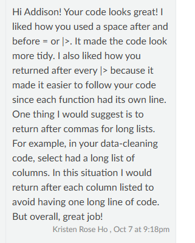

Initially during pair programming, I found it difficult at times because I’m use to sharing my ideas my ideas back and forth in the moment, and sometimes struggle with forming the right questions or recalling how to use functions we learned. However, as we did more practice activities, it became easier to think on my own before asking for help either from my partner or from Dr. T or Jasmine. I got more into the rhythm of asking insightful questions that allow the coder to think on their own without me sharing my ideas.